# Simulating random completion of Multiple-Choice tests

I never liked MC tests as getting a good grade seemed almost impossible because of the minus points and even reaching the satisfactory 50% isn't obvious (unlike for a true-false test). I was interested in how many points could someone expect on average by randomly crossing and what is the statistically best strategy for it.

### Here I aim to get the empirical distribution and expected value achievable by randomly completing an MC test under different conditions.

Parameters:  
Q: number of questions, default  
M: number of answers per question (I made this constant for the whole quiz)  
N: max number of possible answers  
I: number of test iterations (10000 already has a long runtime, I use 50k as default)

3 types of answering:  
A) always cross 1  
B) always cross N  
C) cross a random amount between 1-N

Grading:  
For correct cross: +1/p, p: number of correct answers for that exact q  
For incorr. cross: -0.5, but minimum point per qustion is 0

Output: In the end, we'll only store the final score for each test and show the results that way.

```python
#Import required functions
from numpy import zeros, mean, std, arange
from numpy.random import randint, choice
import matplotlib.pyplot as plt
```

```python
#The main function implemented:

def MC_distribution(answer_type, Q=30, M=5, N=3, I=50000):
    if Q < M | Q < N | M < N:
        print("Wrong parameters")
        return None

    all_points = []
    for _ in range(I): #in each testcase we get a float with the achieved point, collect them
        #create an array QxM, with N 1s per row
        table = zeros(shape=(Q,M))
        for q in range(Q):
            #random amount of random correct answers per row
            corr_per_row = choice(a=[i for i in range(M)],size=randint(1,N+1))
            for k in corr_per_row:
                table[q,k] = 1  #the corr answers are now indexed with 1

        #sample from the rows with "choice" according to answer type
        points = 0
        for row in range(Q):
            qpoint = 0
            p = sum(table[row]) #num of correct answers in that particular row
            if answer_type is "A":
                crosses = choice(a=table[row],size=1)
            elif answer_type is "B":
                crosses = choice(a=table[row],size=N) #here it's not N+1!
            elif answer_type is "C":
                crosses = choice(a=table[row],size=randint(1,N+1))
            #grade the question
            for cross in crosses:
                if cross == 0:
                    qpoint -= 0.5 #incorr
                else:
                    qpoint += 1/p #corr

            if qpoint < 0: #point per question can't be negative
                qpoint = 0

            points += qpoint #add points together for current test
        all_points.append(points) #store the achieved points
    return all_points
```

The distribution by using answer strategy "A":

```
5.997429999999999 1.6863031741356593
```

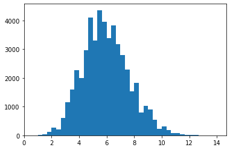

```python
apa = MC_distribution("A")
print(mean(apa), std(apa))

plt.hist(apa, bins=40)
```

The distribution by using answer type "B":

```
6.54993 2.4695970871536472
```

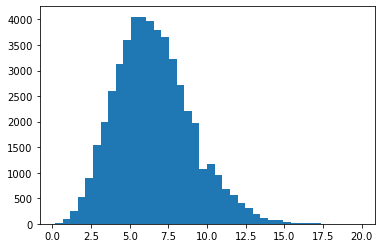

```python
apb = MC_distribution("B")
print(mean(apb), std(apb))

plt.hist(apb, bins=40)
```

The distribution by using answer type "C":

```
6.228603333333332 2.113688183770518
```

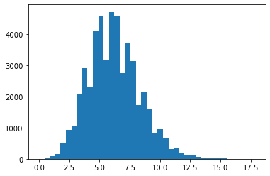

```python
apc = MC_distribution("C")
print(mean(apc), std(apc))

plt.hist(apc, bins=40)
```

Example: Reducing the test to single choice case with N=1.

```
6.00504 2.185162373463354
```

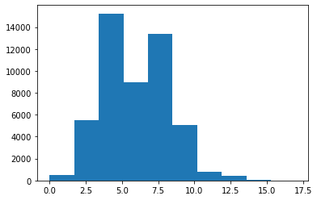

```python
sca = MC_distribution("A",N=1)
print(mean(sca), std(sca))

plt.hist(sca)
```

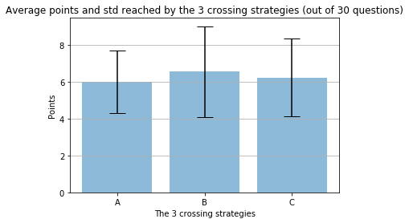

```python
#showing the results in a plot
strats = ['A', 'B', 'C']
x_pos = arange(len(strats))
means = [mean(apa), mean(apb), mean(apc)]
error = [std(apa), std(apb), std(apc)]

fig, ax = plt.subplots()
ax.bar(x_pos, means, yerr=error, align='center', alpha=0.5, ecolor='black', capsize=10)
ax.set_ylabel('Points')
ax.set_xlabel('The 3 crossing strategies')
ax.set_xticks(x_pos)
ax.set_xticklabels(strats)
ax.set_title('Average points and std reached by the 3 crossing strategies (out of 30 questions)')
ax.yaxis.grid(True)
```

## Discussion:

### The best strategy

The highest average is achievable by "B" - crossing the most crosses per question that one can (eg. 3 if we know that there can be max 3 correct answers). This is an interesting find as in my mind the strategy for guessing was to only cross one ("A"), trying to avoid incorrect answers that could potentially ruin a correct one. However, the B strategy has a lot higher variance (std) and therefore a high risk/ high reward option, so to minimize variance and go for the safer way is still to only cross 1. Randomly choosing the number of crosses every time ("C") is worse than both others as it doesn't result much higher average point as "A" but has almost as high variance as "B".

### Distribution

We can observe that the distributions follow some bell curve. As the data points are the function of summing up points from questions (equivalent to averaging the points, because we add the same amount every time), which all come from some distribution, the central limit theorem is called but not in a imprecise way, as the distribution of the points for individual questions are slightly different (depends on the amount of crosses and correct answers, which change). Therefore a bell curve shows in every experiment, but not a precise gaussian curve.